# Explore and summarize Data Project

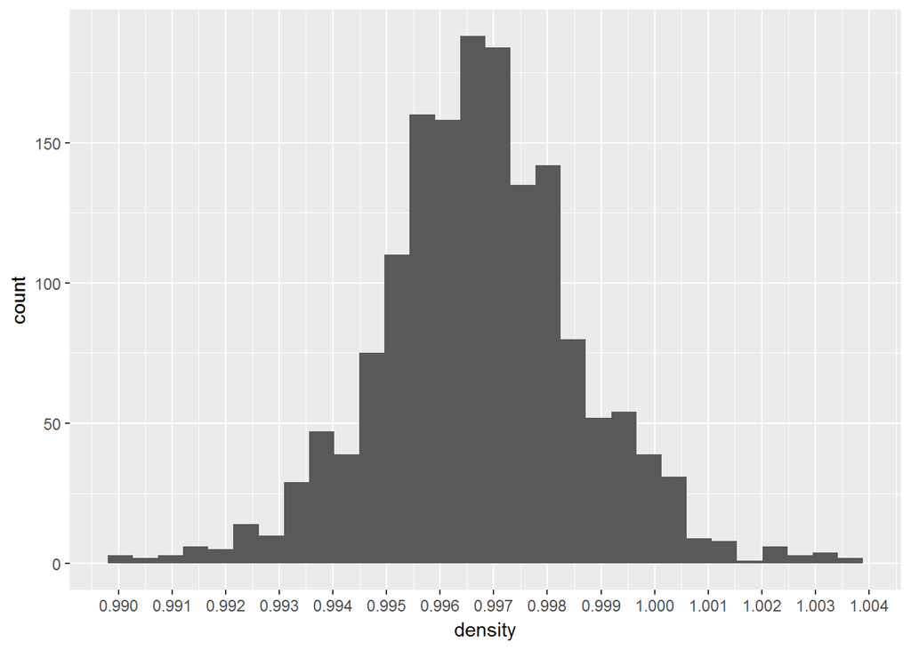

```
##    Min. 1st Qu.  Median    Mean 3rd Qu.    Max.
##  0.9901  0.9956  0.9968  0.9967  0.9978  1.0037
```

Density data is approximately normal, with a minimum of 0.9901, a maximum of 1.0037, mean 0.9967 and median 0.9968. Most of the values are between 0.994 and 0.999, it seems like the density is almost equal for all wines, I wonder if it affects the quality of the wine.

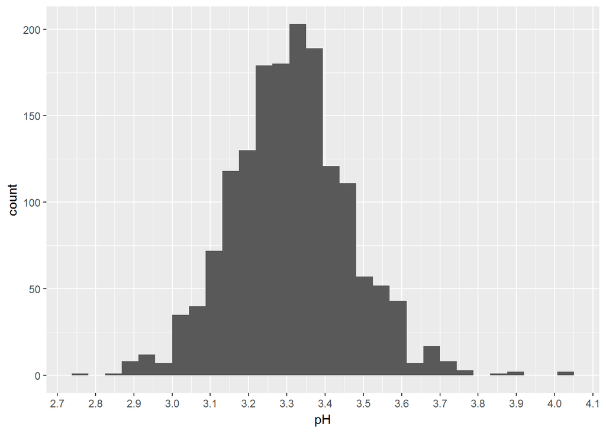

```
##    Min. 1st Qu.  Median    Mean 3rd Qu.    Max.
##   2.740   3.210   3.310   3.311   3.400   4.010
```

pH has also an approximately normal distribution, but in this case some outliers are easily identified at approximately a value of 4. pH has a minimum value of 2.74, a maximum of 4.01, with a median of 3.31 and mean 3.311. Most values are between a value of 3.1 and 3.5.

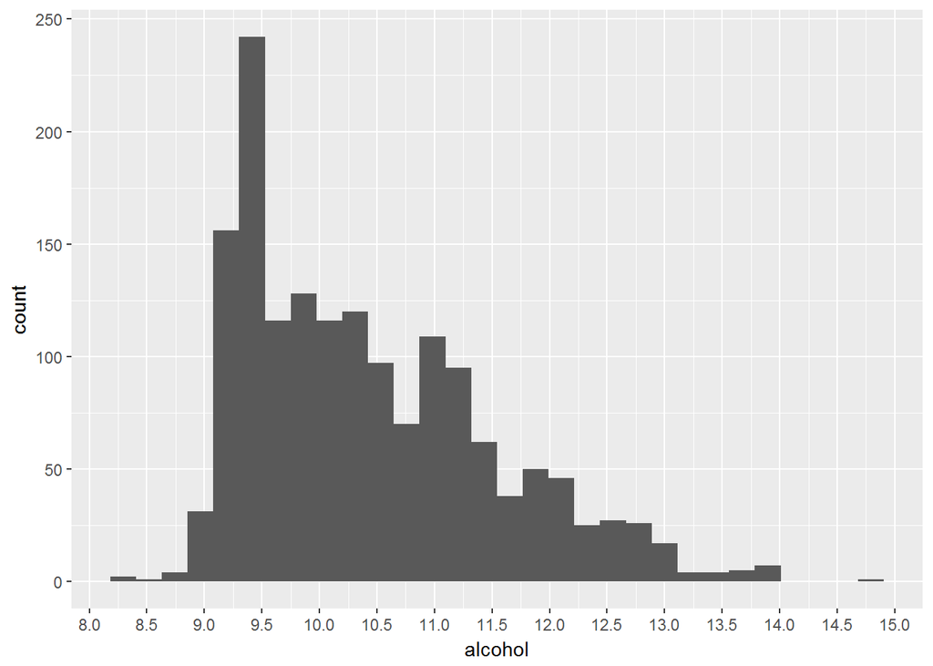

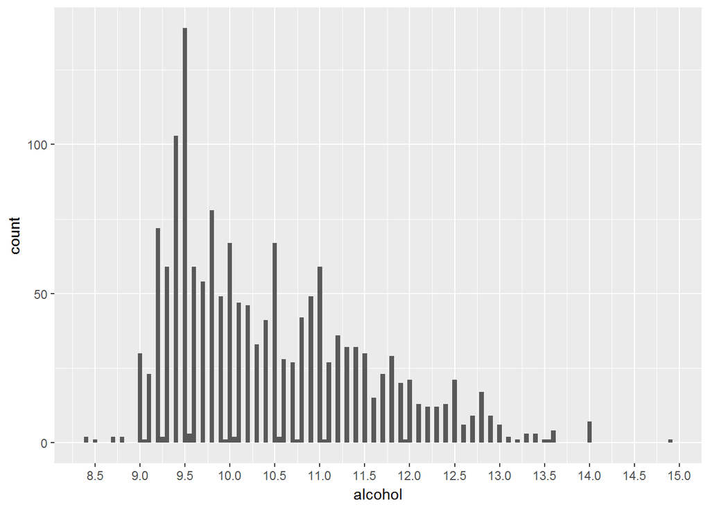

```
##    Min. 1st Qu.  Median    Mean 3rd Qu.    Max.
##    8.40    9.50   10.20   10.42   11.10   14.90
```

```
##
##              8.4              8.5              8.7              8.8
##                2                1                2                2
##                9             9.05              9.1              9.2
##               30                1               23               72
## 9.23333333333333             9.25              9.3              9.4
##                1                1               59              103
##              9.5             9.55 9.56666666666667              9.6
##              139                2                1               59
##              9.7              9.8              9.9             9.95
##               54               78               49                1
##               10 10.0333333333333             10.1             10.2
##               67                2               47               46
##             10.3             10.4             10.5            10.55
##               33               41               67                2
##             10.6             10.7            10.75             10.8
##               28               27                1               42
##             10.9               11 11.0666666666667             11.1
##               49               59                1               27
##             11.2             11.3             11.4             11.5
##               36               32               32               30
##             11.6             11.7             11.8             11.9
##               15               23               29               20
##            11.95               12             12.1             12.2
##                1               21               13               12
##             12.3             12.4             12.5             12.6
##               12               13               21                6
##             12.7             12.8             12.9               13
##                9               17                9                6
##             13.1             13.2             13.3             13.4
##                2                1                3                3
##             13.5 13.5666666666667             13.6               14
##                1                1                4                7
##             14.9
##                1
```

The alcohol data distribution is not normal but did not need a transformation to be easily understandable. Adjusting the binwidth we can notice two peaks at values of 9.5 and 9.4 and a decreasing frequency as values go higher. Alcohol has a min. value of 8.4, max of 14.9, mean of 10.42 and median 10.2

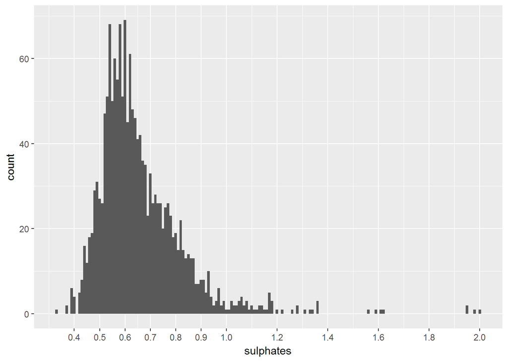

```
##    Min. 1st Qu.  Median    Mean 3rd Qu.    Max.
##  0.3300  0.5500  0.6200  0.6581  0.7300  2.0000
```

Sulphates values have a maximum of 2, a minumum of 0.33, median 0.62 and Mean 0.6581. Most common values are between 0.52 and 0.73, with diminishing frequencies to the right and left.

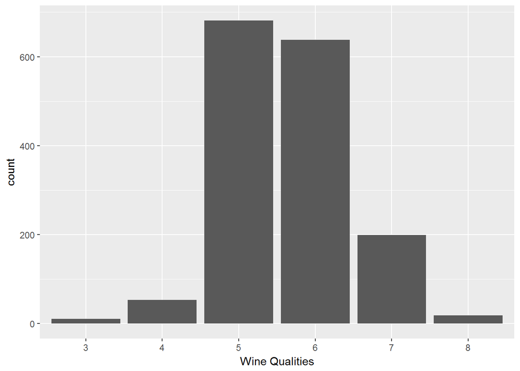

```
##    Min. 1st Qu.  Median    Mean 3rd Qu.    Max.
##   3.000   5.000   6.000   5.636   6.000   8.000
```

```
##
##   3   4   5   6   7   8
##  10  53 681 638 199  18
```

Quality values in our dataset have a min. of 3, max. of 8, median of 6 and mean of 5.636.

# Univariate Analysis

### What is the structure of your dataset?

There are 1599 wines in the dataset with 11 attributes each and one output variable, all of them are numeric.

Input variables are: fixed acidity (tartaric acid - g / dm^3), volatile acidity (acetic acid - g / dm^3), citric acid (g / dm^3), residual sugar (g / dm^3), chlorides (sodium chloride - g / dm^3), free sulfur dioxide (mg / dm^3), total sulfur dioxide (mg / dm^3), density (g / cm^3), pH, sulphates (potassium sulphate - g / dm3), alcohol (% by volume)

The output variable is quality (score between 0 and 10).

The description of variables (taken from the documentation of the dataset) is:

1 - fixed acidity: most acids involved with wine or fixed or nonvolatile (do not evaporate readily).

2 - volatile acidity: the amount of acetic acid in wine, which at too high of levels can lead to an unpleasant, vinegar taste.

3 - citric acid: found in small quantities, citric acid can add ‘freshness’ and flavor to wines.

4 - residual sugar: the amount of sugar remaining after fermentation stops, it’s rare to find wines with less than 1 gram/liter and wines with greater than 45 grams/liter are considered sweet.

5 - chlorides: the amount of salt in the wine.

6 - free sulfur dioxide: the free form of SO2 exists in equilibrium between molecular SO2 (as a dissolved gas) and bisulfite ion; it prevents microbial growth and the oxidation of wine.

7 - total sulfur dioxide: amount of free and bound forms of S02; in low concentrations, SO2 is mostly undetectable in wine, but at free SO2 concentrations over 50 ppm, SO2 becomes evident in the nose and taste of wine.

8 - density: the density of water is close to that of water depending on the percent alcohol and sugar content.

9 - pH: describes how acidic or basic a wine is on a scale from 0 (very acidic) to 14 (very basic); most wines are between 3-4 on the pH scale.

10 - sulphates: a wine additive which can contribute to sulfur dioxide gas (S02) levels, wich acts as an antimicrobial and antioxidant.

11 - alcohol: the percent alcohol content of the wine

Other observations:

- Most variables had right skewness.
- Volatile acidity seems bimodal.
- Outliers were present in almost all variables.
- pH and density value distributions are very likely to be normal.
- Very poor and very good qualities are quite rare in the dataset.

### What is/are the main feature(s) of interest in your dataset?

The main feature in the data set is quality. I’d like to determine which features are best for predicting the quality of a wine. Since I have no prior knowledge of what affects the quality of wines, my suspicions are limited to the description of the variables.

### What other features in the dataset do you think will help support your investigation into your feature(s) of interest?

For it’s description, I think that volatile acidity is directly negatively correlated to quality.

I also think alcohol may have more importance than other variables in the quality of the wine, because it is so easily to perceive as the wine is a drink that is not normally mixed with other fluids.

### Did you create any new variables from existing variables in the dataset?

No, but as I continue the analysis it is very likely that I combine two very related variables into a single one that explains changes in quality better.

### Of the features you investigated, were there any unusual distributions? Did you perform any operations on the data to tidy, adjust, or change the form of the data? If so, why did you do this?

I log-transformed all the the skewed distributions if I considered the count of a single bin was to high compared to others or if I suspected the distribution of a variable would be more understandable if I did so. The variables in which I did this are citric acid, residual sugar, chlorides, free sulfur dioxide and total sulfur dioxide.

The volatile acidity distribution seems bimodal, and for qualities I was expecting the distribution to have at least some wines of quality 1, 2, 9 and 10, but there weren’t.

# Bivariate Plots Section

The next is a pearson correlation matrix.

```
##                      fixed.acidity volatile.acidity citric.acid
## fixed.acidity                 1.00            -0.26        0.67
## volatile.acidity             -0.26             1.00       -0.55
## citric.acid                   0.67            -0.55        1.00
## residual.sugar                0.11             0.00        0.14
## chlorides                     0.09             0.06        0.20
## free.sulfur.dioxide          -0.15            -0.01       -0.06
## total.sulfur.dioxide         -0.11             0.08        0.04
## density                       0.67             0.02        0.36
## pH                           -0.68             0.23       -0.54
## sulphates                     0.18            -0.26        0.31
## alcohol                      -0.06            -0.20        0.11
## quality                       0.12            -0.39        0.23
##                      residual.sugar chlorides free.sulfur.dioxide
## fixed.acidity                  0.11      0.09               -0.15
## volatile.acidity               0.00      0.06               -0.01
## citric.acid                    0.14      0.20               -0.06
## residual.sugar                 1.00      0.06                0.19
## chlorides                      0.06      1.00                0.01
## free.sulfur.dioxide            0.19      0.01                1.00
## total.sulfur.dioxide           0.20      0.05                0.67
## density                        0.36      0.20               -0.02
## pH                            -0.09     -0.27                0.07
## sulphates                      0.01      0.37                0.05
## alcohol                        0.04     -0.22               -0.07
## quality                        0.01     -0.13               -0.05
##                      total.sulfur.dioxide density    pH sulphates alcohol
## fixed.acidity                       -0.11    0.67 -0.68      0.18   -0.06
## volatile.acidity                     0.08    0.02  0.23     -0.26   -0.20
## citric.acid                          0.04    0.36 -0.54      0.31    0.11
## residual.sugar                       0.20    0.36 -0.09      0.01    0.04
## chlorides                            0.05    0.20 -0.27      0.37   -0.22
## free.sulfur.dioxide                  0.67   -0.02  0.07      0.05   -0.07
## total.sulfur.dioxide                 1.00    0.07 -0.07      0.04   -0.21
## density                              0.07    1.00 -0.34      0.15   -0.50
## pH                                  -0.07   -0.34  1.00     -0.20    0.21
## sulphates                            0.04    0.15 -0.20      1.00    0.09
## alcohol                             -0.21   -0.50  0.21      0.09    1.00
## quality                             -0.19   -0.17 -0.06      0.25    0.48
##                      quality
## fixed.acidity           0.12
## volatile.acidity       -0.39
## citric.acid             0.23
## residual.sugar          0.01
## chlorides              -0.13
## free.sulfur.dioxide    -0.05
## total.sulfur.dioxide   -0.19
## density                -0.17
## pH                     -0.06
## sulphates               0.25
## alcohol                 0.48
## quality                 1.00
```

-Total sulfur dioxide is related with free sulfur dioxide, which was someway obvious.

-One unexpected high correlation is the one of the fixed acidity with density of the wine, fixed acidity is also highly correlated with citric acid and pH.

-Density and alcohol are fairly correlated.

-As expected, volatile acidity and alcohol affect the quality most, followed by sulphates and citric acid.

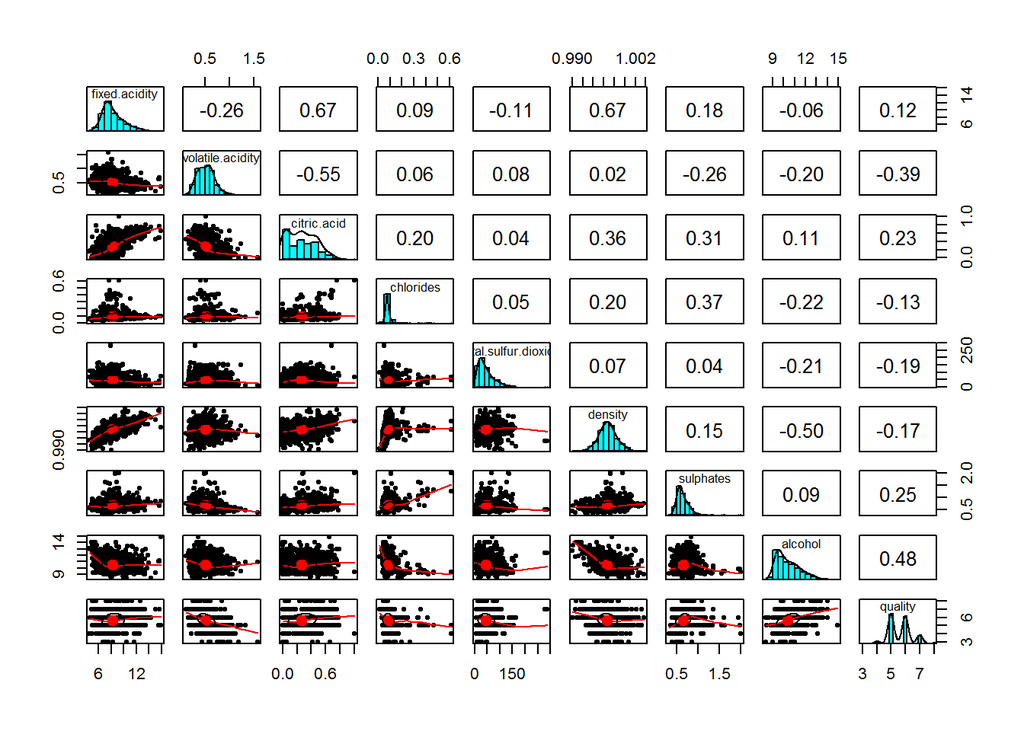

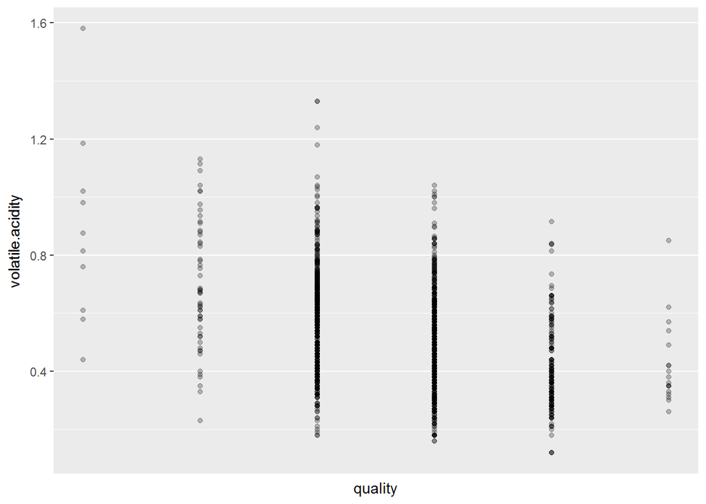

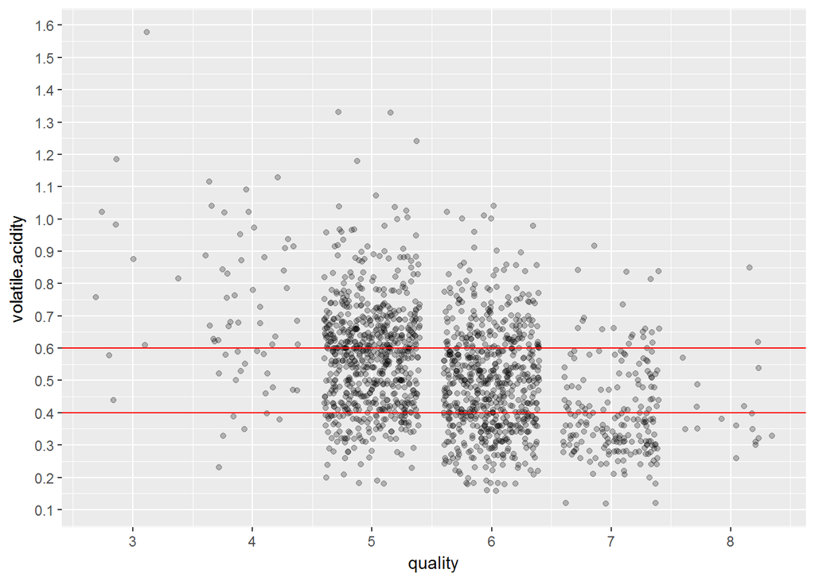

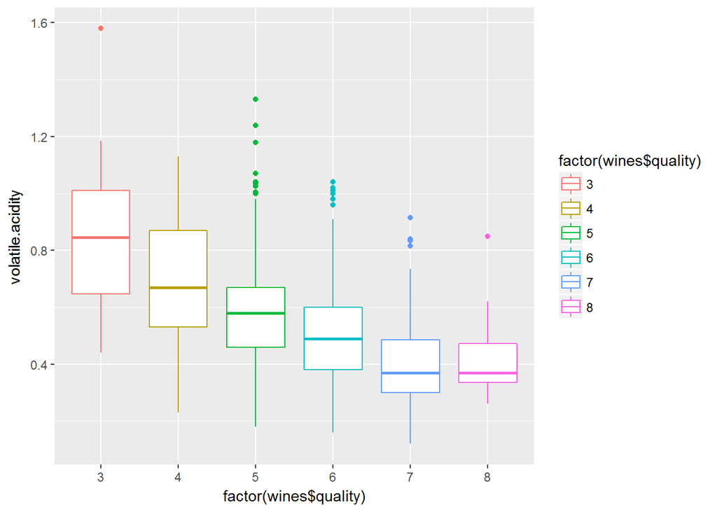

After preventing the points from overplotting and as expected, as the volatile acidity values goes higher, the unpleasant vinegar taste increases and the wines tend to be considered of less quality. Still, wines with the highest qualities are not the wines with the lowest volatile acidities.

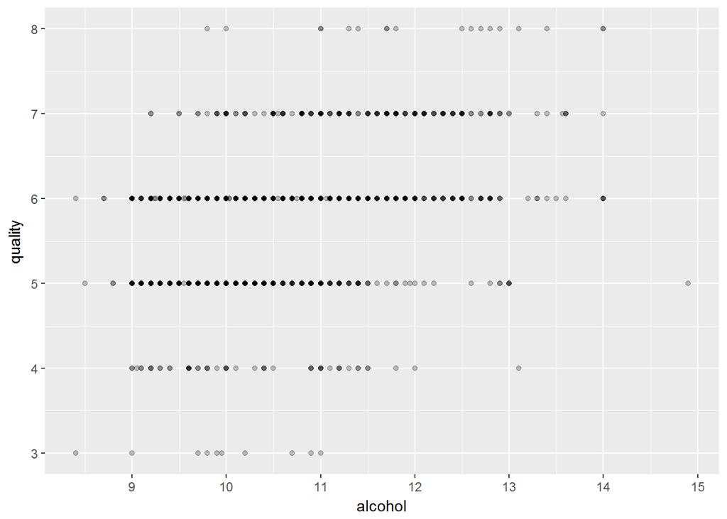

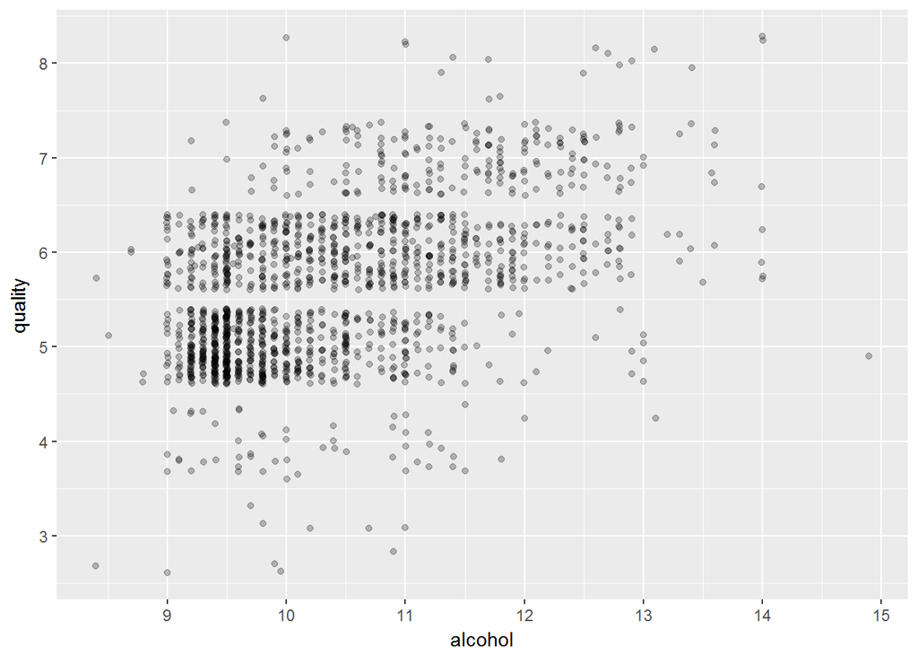

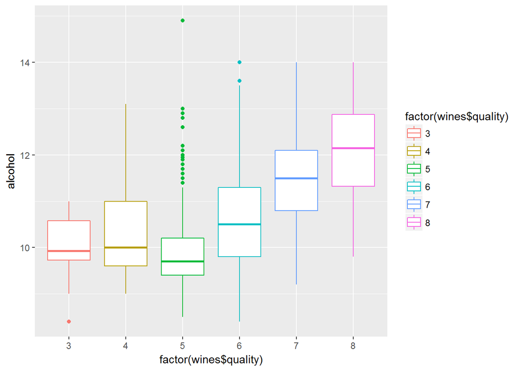

Since alcohol is the variable with the highest correlation to quality, visualizing a more detailed scatterplot was obligatory. I prevented points from overplotting with an alpha value = 0.25, and used geom_jitter() to get an idea of a more realistic continuous quality distribution.

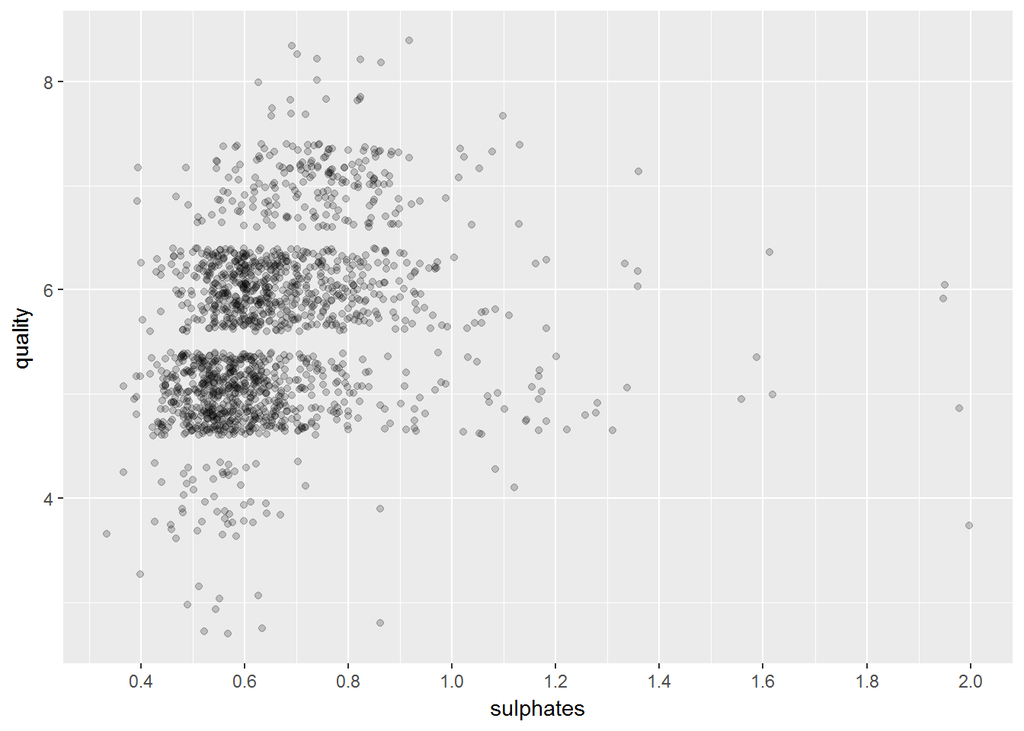

The correlation is not very strong here, but there is a small trend of higher quality wines to have slightly higher sulphates values.

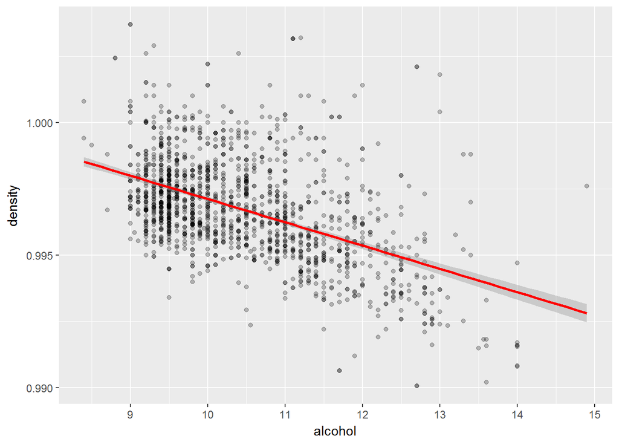

As the alcohol percentage increases, the density of the wine lowers. Combining this finding with previous plots, this means that we can later expect to find that wines of higher quality, have a slightly lower density.

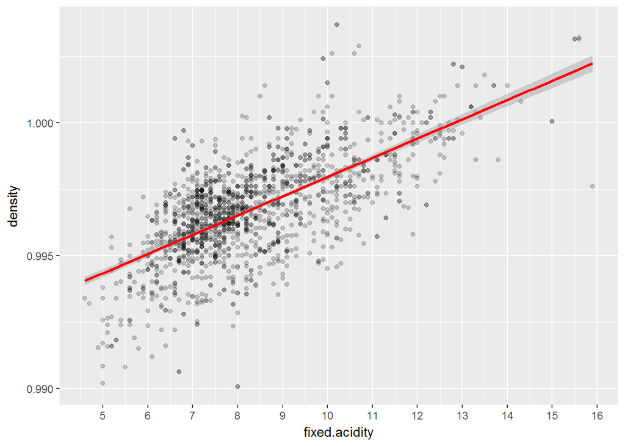

The relationship between fixed acidity with density can almost be approximated with a linear model.

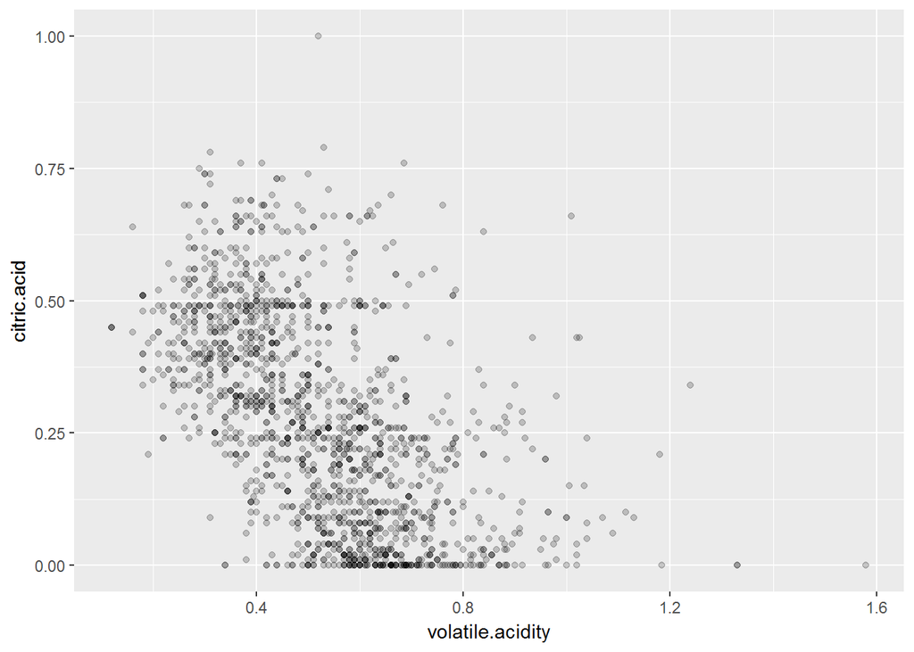

We can perceive a negative linear relation between volatile acidity and citric acid. Since quality also has a negative relatively linear relation with acidity, it makes sense to expect qualities a bit higher for higher citric acid values in wines.

# Bivariate Analysis

### Talk about some of the relationships you observed in this part of the investigation. How did the feature(s) of interest vary with other features in the dataset?

-One unexpected high correlation is the one of the fixed acidity with density of the wine, fixed acidity is also highly correlated with citric acid and pH.

-Density and alcohol are fairly correlated with a negative pearson correlation coefficient.

-Volatile acidity and citric acid are fairly correlated with a negative pearson correlation coefficient.

-Quality has the strongest relations with volatile acidity and alcohol with a negative and positive pearson correlation cofficient respectively, followed by sulphates and citric acid, both with small pearson correlation coefficients.

### Did you observe any interesting relationships between the other features (not the main feature(s) of interest)?

- Alcohol with density and fixed acidity with density correlations were interesting for me to find.

### What was the strongest relationship you found?

- I did expect fixed acidity to correlate a lot (-0.68 pearson correlation coefficient) with pH. Which is the highest of all coefficients between variables.

# Multivariate Plots Section

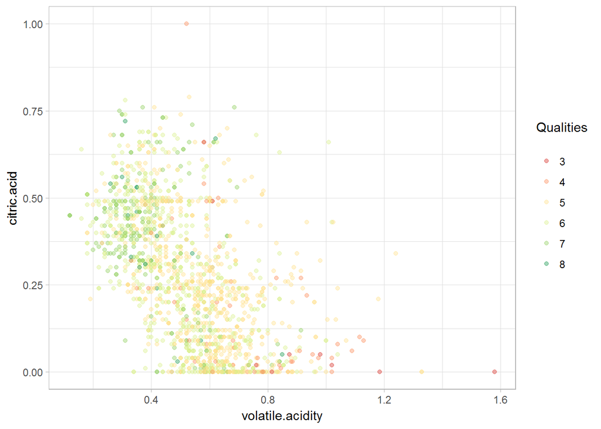

Citric acid and volatile acidity have one of the highest negative pearson correlation coefficient of all variables, so I wanted to see how qualities vary as this two variables increase or decrease between them.

The resulting plot let us see as expected a tendency for lower volatile acidity values and higher citric acid values for higher quality wines.

[output not shown]

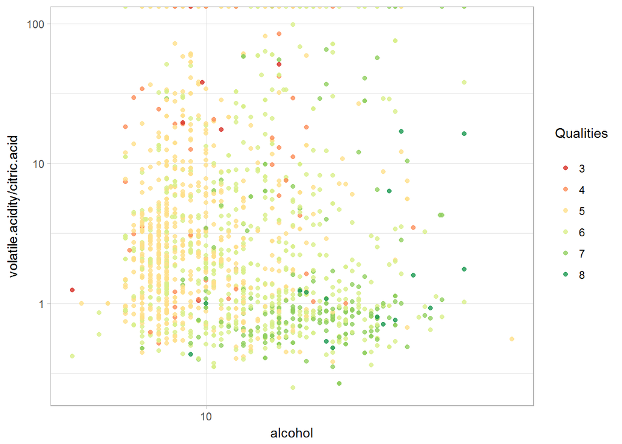

This is my first attempt to create a new variable (volatile.acidity/citric.acid) that clearly differentiates different wine qualities when plotted against another variable that we already know tends to affect wine quality (alcohol).

The resulting plot does not accomplish this differentiation as much as I would want for middle qualities (5 and 6), but it does let us see a tendency for highest quality wines (7 and 8) to have more percent alcohol while also having less volatile.acidity/citric.acid.